# Escogiendo un Hogar

Jefferson Santiago

# Instalación y declaración de paquetes utilizados

```r
#install.packages('curl')
#install.packages('xlsx')
library('curl')
library('xlsx')
```

# Leemos el archivo hogares.xlsx

```r
hogar_datos <- read.xlsx2("hogares.xlsx", sheetIndex = 1, startRow = 1, endRow = 104, header = T,
                          encoding = 'UTF-8')
```

# Eliminamos las columnas Piso y Foto ya que son irrelevantes.

```r
hogar_datos$Piso <- NULL
hogar_datos$Foto <- NULL
```

# Numerizamos la columna Tipo.de.Inmueble utilizando la función grepl para usar expresiones regulares.

## Los valores serán cambiados de la siguiente manera:

### 0 para Appartamento, 1 para Mini Appartamento o Monolocale.

```r
hogar_datos$Tipo.de.Inmueble <- as.character(hogar_datos$Tipo.de.Inmueble)
hogar_datos$Tipo.de.Inmueble[grepl("Mini", hogar_datos$Tipo.de.Inmueble)] <- '1'
hogar_datos$Tipo.de.Inmueble[grepl("Ap", hogar_datos$Tipo.de.Inmueble)] <- '0'
hogar_datos$Tipo.de.Inmueble[grepl("Monolocale", hogar_datos$Tipo.de.Inmueble)] <- '1'
hogar_datos$Tipo.de.Inmueble <- as.numeric(hogar_datos$Tipo.de.Inmueble)
```

# Siguiente paso, se crearán columnas para cada variable almacenada en Descrición (Solo las que se describen en el enunciado),

### variables como: bagni, si tiene ingreso, camera, cucina, riscaldamento, condominio.

```r
hogar_datos$Descripción <- as.character(hogar_datos$Descripción)
```

## Creamos la coluumna de ingreso para numerizar si tiene ingreso o no, con 1 y 0 respectivamente.

```r
hogar_datos$ingreso <- '0'
hogar_datos$ingreso[grepl("Ingresso", hogar_datos$Descripción)] <- '1'
```

## Creamos la coluumna de habitacion para numerizar la cantidad de camere.

```r
hogar_datos$nroHabitaciones <- '0'
hogar_datos$nroHabitaciones[grepl("camera", hogar_datos$Descripción)] <- '1'
hogar_datos$nroHabitaciones[grepl("2.camer|2.camer|2camer|2camer", hogar_datos$Descripción)] <- '2'
hogar_datos$nroHabitaciones[grepl("3.camer|3.camer|3camer|3camer| tre.camer", hogar_datos$Descripción)] <- '3'
hogar_datos$nroHabitaciones[grepl("4.camer|4.camer|4camer|4camer", hogar_datos$Descripción)] <- '4'
hogar_datos$nroHabitaciones[grepl("5.camer|5.camer|5camer|5camer", hogar_datos$Descripción)] <- '5'
```

## Creamos la coluumna de cocina para numerizar si tiene o no coucine.

```r
hogar_datos$cocina <- '0'
hogar_datos$cocina[grepl("cina", hogar_datos$Descripción)] <- '1'
```

## Creamos la coluumna de baños para numerizar la cantidad de baños.

```r
hogar_datos$nroBanos <- '0'
hogar_datos$nroBanos[grepl("bagno", hogar_datos$Descripción)] <- '1'
hogar_datos$nroBanos[grepl("2.bagn|2bagn", hogar_datos$Descripción)] <- '2'
hogar_datos$nroBanos[grepl("3.bagn|3bagn", hogar_datos$Descripción)] <- '3'
hogar_datos$nroBanos[grepl("4.bagn|4bagn", hogar_datos$Descripción)] <- '4'
```

## Creamos la coluumna de calefaccion para numerizar riscaldamento.

```r
hogar_datos$calefaccion <- '0'
hogar_datos$calefaccion[grepl("riscaldamento|TUTTO", hogar_datos$Precio.Mensual)] <- '1'
```

## Creamos la coluumna de condominio para numerizar condominio.

```r
hogar_datos$condominio <- '0'
hogar_datos$condominio[grepl("condominio|TUTTO|conominio", hogar_datos$Precio.Mensual)] <- '1'
```

## Creamos la columna de genero. 0 para hombres, 1 para mujeres y 2 para ambos géneros.

```r
hogar_datos$genero <- '-1'
hogar_datos$genero[grepl("ragazzi", hogar_datos$Notas)] <-  '0'
hogar_datos$genero[grepl("ragazze", hogar_datos$Notas)] <-  '1'
hogar_datos$genero[grepl('ragazze/i|ragazzi/e|ragazzi/ragazze|ragazze/ragazzi', hogar_datos$Notas)] <-  '2'
# si no especifican el genero, se asume que se aceptan ambos generos
hogar_datos$genero[grepl('-1', hogar_datos$genero)] <-  '2'
```

## Creamos la columna de cargosPorServicio 0 para especificar que no incluye, 1 para especificar que si.

```r
hogar_datos$cargosPorServicio <- '0'
hogar_datos$cargosPorServicio[grepl("spese escluse|spese", hogar_datos$Precio.Mensual)] <-  '1'
```

## Creamos una columna para el precio y otra para el tipo de habitacion.

## 0 para habitación simple, 1 para habitación doble(tomo la habitación doble como posto letto),

## 1 para posto letto y 2 para intero Appartamento

## La información en el siguiente paso corresponde a los que tienen solo un tipo de habitación disponible

## con un precio en específico

## El monolocale se tomó como simple y mini apartamento como apartamento.

```r
hogar_datos$precio <- '-1'
hogar_datos$tipoHabitacion <- '-1'
hogar_datos$Habitaciones.Disponibles <- as.character(hogar_datos$Habitaciones.Disponibles)
hogar_datos$Precio.Mensual <- as.character(hogar_datos$Precio.Mensual)
for (row in 1:nrow(hogar_datos)){
  precios_num <- strsplit(hogar_datos$Precio.Mensual[row], '\\D+')
  precios_num <- unlist(precios_num)[2:length(unlist(precios_num))]
  # print(precios_num)
  if (length(precios_num) == 1){
    hogar_datos$precio[row] <- as.numeric(precios_num[1])
    if (grepl("ingol", hogar_datos$Habitaciones.Disponibles[row])) hogar_datos$tipoHabitacion[row] <- '0'
    # Tome los las habitaciones "posto letto" y "doppia" como si fueran del mismo tipo ya que en todas las
    # apariciones que sale doppia, en el precio mensual nombran que se refieren a un posto letto.
    if (grepl("doppi", hogar_datos$Habitaciones.Disponibles[row])) hogar_datos$tipoHabitacion[row] <- '1'
    if (grepl("posto", hogar_datos$Habitaciones.Disponibles[row])) hogar_datos$tipoHabitacion[row] <- '1'
    if (grepl("parta", hogar_datos$Habitaciones.Disponibles[row])) hogar_datos$tipoHabitacion[row] <- '2'
  }
}
```

## Los registros restantes no procesados en el paso anterior, se procesarán a continuación:

```r
hogar_datos$tipoHabitacion[90] <- '0'
# Fila 4: 1 doppia e/o uso singola € 450; € 300 a posto letto...
row <- hogar_datos[4,]
row$tipoHabitacion <- '1'
row$precio <- '450'
hogar_datos$tipoHabitacion[4] <- '0'
hogar_datos$precio[4] <- '300'
hogar_datos <- rbind(hogar_datos, row)
# Fila 5: 2 singole 2 singole € 450; € 450; € 55,00 per le spese
row <-  hogar_datos[5,]
row$tipoHabitacion <- '0'
row$precio <- '450'
hogar_datos$tipoHabitacion[5] <- '0'
hogar_datos$precio[5] <- '450'
hogar_datos <- rbind(hogar_datos, row)
# Fila 7: 2 1 doppia e/o uso singola € 450; € 250 a posto letto; spese escluse
row <- hogar_datos[7,]
row$tipoHabitacion <- '1'
row$precio <- '450'
hogar_datos$tipoHabitacion[7] <- '0'
hogar_datos$precio[7] <- '250'
hogar_datos <- rbind(hogar_datos, row)
# Fila 10: 1 singola; 1 doppia; € 550 singola, € 350 posto letto TUTTO INCLUSO
row <- hogar_datos[10,]
row$tipoHabitacion <- '0'
row$precio <- '550'
hogar_datos$tipoHabitacion[10] <- '1'
hogar_datos$precio[10] <- '350'
hogar_datos <- rbind(hogar_datos, row)
# Fila 16: 4 singole € 460; € 460; € 430; € 430; condominio e riscaldamento inclusi
row <- hogar_datos[16,]
row$tipoHabitacion <- '0'
row$precio <- '460'
hogar_datos <- rbind(hogar_datos, row)
row$tipoHabitacion <- '0'
row$precio <- '460'
hogar_datos <- rbind(hogar_datos, row)
row$tipoHabitacion <- '0'
row$precio <- '430'
hogar_datos <- rbind(hogar_datos, row)
hogar_datos$tipoHabitacion[16] <- '0'
hogar_datos$precio[16] <- '430'
# Fila 18: 2 singole € 450; € 400; € 50/mese condominio e riscaldamento
row <- hogar_datos[18,]
row$tipoHabitacion <- '0'
row$precio <- '450'
hogar_datos <- rbind(hogar_datos, row)
hogar_datos$tipoHabitacion[18] <- '0'
hogar_datos$precio[18] <- '400'
# Fila 21: 3 singole € 475; € 525; € 575; TUTTO INCLUSO
row <- hogar_datos[21,]
row$tipoHabitacion <- '0'
row$precio <- '475'
hogar_datos <- rbind(hogar_datos, row)
row$precio <- '525'
hogar_datos <- rbind(hogar_datos, row)
hogar_datos$tipoHabitacion[21] <- '0'
hogar_datos$precio[21] <- '575'
# Fila 22: 2 singole € 525; € 575; TUTTO INCLUSO
row <- hogar_datos[22,]
row$tipoHabitacion <- '0'
row$precio <- '525'
hogar_datos <- rbind(hogar_datos, row)
hogar_datos$tipoHabitacion[22] <- '0'
hogar_datos$precio[22] <- '575'
# Fila 23: 3 singole € 475; € 525; € 575; TUTTO INCLUSO
row <- hogar_datos[23,]
row$tipoHabitacion <- '0'
row$precio <- '475'
hogar_datos <- rbind(hogar_datos, row)
row$precio <- '525'
hogar_datos <- rbind(hogar_datos, row)
hogar_datos$tipoHabitacion[23] <- '0'
hogar_datos$precio[23] <- '575'
# Fila 24: 3 singole € 380; €380; € 350; internet incluso
row <- hogar_datos[24,]
row$tipoHabitacion <- '0'
row$precio <- '380'
hogar_datos <- rbind(hogar_datos, row)
row$precio <- '380'
hogar_datos <- rbind(hogar_datos, row)
hogar_datos$tipoHabitacion[24] <- '0'
hogar_datos$precio[24] <- '350'
# Fila 26: 3 singole € 400; € 420; € 380; condominio e acqua inclusi
row <- hogar_datos[26,]
row$tipoHabitacion <- '0'
row$precio <- '400'
hogar_datos <- rbind(hogar_datos, row)
row$precio <- '420'
hogar_datos <- rbind(hogar_datos, row)
hogar_datos$tipoHabitacion[26] <- '0'
hogar_datos$precio[26] <- '380'
# Fila 31: 1 Singola / uso doppia € 450 singola; € 250 posto letto; condominio e riscaldamento inclusi
row <- hogar_datos[31,]
row$tipoHabitacion <- '0'
row$precio <- '450'
hogar_datos <- rbind(hogar_datos, row)
hogar_datos$tipoHabitacion[31] <- '1'
hogar_datos$precio[31] <- '250'
# Fila 41: 2 singole € 350; € 450; condominio e acqua inclusi
row <- hogar_datos[41,]
row$tipoHabitacion <- '0'
row$precio <- '350'
hogar_datos <- rbind(hogar_datos, row)
hogar_datos$tipoHabitacion[41] <- '0'
hogar_datos$precio[41] <- '450'
# Fila 42: 4 singole € 500; € 450; € 450; € 420 condominio, acqua, riscaldamento e tassa rifiuti inclusi..
row <- hogar_datos[42,]
row$tipoHabitacion <- '0'
row$precio <- '500'
hogar_datos <- rbind(hogar_datos, row)
row$precio <- '450'
hogar_datos <- rbind(hogar_datos, row)
row$precio <- '450'
hogar_datos <- rbind(hogar_datos, row)
hogar_datos$tipoHabitacion[42] <- '0'
hogar_datos$precio[42] <- '420'
# Fila 43: 2 singole € 450; € 500; condominio, acqua e tassa rifiuti inclusi..
row <- hogar_datos[43,]
row$tipoHabitacion <- '0'
row$precio <- '500'
hogar_datos <- rbind(hogar_datos, row)
hogar_datos$tipoHabitacion[43] <- '0'
hogar_datos$precio[43] <- '450'
# Fila 44: 3 singole con bagno privato € 400; € 370; € 340; spese escluse...
row <- hogar_datos[44,]
row$tipoHabitacion <- '0'
row$precio <- '400'
hogar_datos <- rbind(hogar_datos, row)
row$precio <- '370'
hogar_datos <- rbind(hogar_datos, row)
hogar_datos$tipoHabitacion[44] <- '0'
hogar_datos$precio[44] <- '340'
# Fila 56: 3 singola € 550; € 500; € 450; condominio, acqua e riscaldamento
row <- hogar_datos[56,]
row$tipoHabitacion <- '0'
row$precio <- '550'
hogar_datos <- rbind(hogar_datos, row)
row$precio <- '500'
hogar_datos <- rbind(hogar_datos, row)
hogar_datos$tipoHabitacion[56] <- '0'
hogar_datos$precio[56] <- '450'
# Fila 61: 3 singole €425; € 450; € 475; condominio, acqua e riscaldamento
row <- hogar_datos[61,]
row$tipoHabitacion <- '0'
row$precio <- '425'
hogar_datos <- rbind(hogar_datos, row)
row$precio <- '450'
hogar_datos <- rbind(hogar_datos, row)
hogar_datos$tipoHabitacion[61] <- '0'
hogar_datos$precio[61] <- '475'
# Fila 72: 1 singola; 1 posto letto € 430 singola; € 350 posto letto; TUTTO INCLUSO
row <- hogar_datos[72,]
row$tipoHabitacion <- '0'
row$precio <- '430'
hogar_datos <- rbind(hogar_datos, row)
hogar_datos$tipoHabitacion[72] <- '1'
hogar_datos$precio[72] <- '350'
# Fila 74: 1 Singole € 350; € 450; Spese escluse
hogar_datos$tipoHabitacion[74] <- '0'
hogar_datos$precio[74] <- '350'
# Fila 76: 2 singole € 850 intero appartamento; € 425 singola; conominio, acqua e riscaldamento inclusi..
row <- hogar_datos[76,]
row$tipoHabitacion <- '0'
row$precio <- '850'
hogar_datos <- rbind(hogar_datos, row)
hogar_datos$tipoHabitacion[76] <- '0'
hogar_datos$precio[76] <- '425'
# Fila 77: 1 singola/uso doppia € 550; € 350 posto letto; condominio, acqua, riscaldamento e tassa rifiuti inclusi
row <- hogar_datos[77,]
row$tipoHabitacion <- '0'
row$precio <- '550'
hogar_datos <- rbind(hogar_datos, row)
hogar_datos$tipoHabitacion[77] <- '1'
hogar_datos$precio[77] <- '350'
# Fila 81: 1 singola/uso doppia;€ 550 singola; € 325 posto letto; TUTTO INCLUSO
row <- hogar_datos[81,]
row$tipoHabitacion <- '0'
row$precio <- '550'
hogar_datos <- rbind(hogar_datos, row)
hogar_datos$tipoHabitacion[81] <- '1'
hogar_datos$precio[81] <- '325'
# Fila 84: 2 singole; 1 doppia € 475; € 525; € 375 posto letto; condominio, acqua, riscaldamento tassa rifiuti inclusa
row <- hogar_datos[84,]
row$tipoHabitacion <- '0'
row$precio <- '475'
hogar_datos <- rbind(hogar_datos, row)
row$precio <- '525'
hogar_datos <- rbind(hogar_datos, row)
hogar_datos$tipoHabitacion[84] <- '1'
hogar_datos$precio[84] <- '375'
# Fila 85: 1 singola; 1 doppia € 450 singola; € 300 posto letto; spese escluse
row <- hogar_datos[85,]
row$tipoHabitacion <- '0'
row$precio <- '450'
hogar_datos <- rbind(hogar_datos, row)
hogar_datos$tipoHabitacion[85] <- '1'
hogar_datos$precio[85] <- '300'
# Fila 87: 2 singole € 475 € 450; condominio, acqua, riscaldamento, tassa rifiuti, internet inclusi
row <- hogar_datos[87,]
row$tipoHabitacion <- '0'
row$precio <- '475'
hogar_datos <- rbind(hogar_datos, row)
hogar_datos$tipoHabitacion[87] <- '0'
hogar_datos$precio[87] <- '450'
# Fila 88: 1 singola; 1 doppia € 450; € 300 posto letto; condominio, acqua, riscaldamento, tassa rifiuti inclusi
row <- hogar_datos[88,]
row$tipoHabitacion <- '0'
row$precio <- '450'
hogar_datos <- rbind(hogar_datos, row)
hogar_datos$tipoHabitacion[88] <- '1'
hogar_datos$precio[88] <- '300'
# Fila 93: 2 singole € 500; € 600; TUTTO INCLUSO
row <- hogar_datos[93,]
row$tipoHabitacion <- '0'
row$precio <- '500'
hogar_datos <- rbind(hogar_datos, row)
hogar_datos$tipoHabitacion[93] <- '0'
hogar_datos$precio[93] <- '600'
# Fila 99: 2 singole € 600; € 550; spese escluse
row <- hogar_datos[99,]
row$tipoHabitacion <- '0'
row$precio <- '550'
hogar_datos <- rbind(hogar_datos, row)
hogar_datos$tipoHabitacion[99] <- '0'
hogar_datos$precio[99] <- '600'
```

# Cargamos el archivo para utilizar el api de google e inicializamos el valor de la api_key

```r
source('google_api.R')
api_key = 'AIzaSyDu45StBRnSVvZc7znYibb7ywxkYar_974'
```

# Me aseguro que sean caracteres Dirección y distrito, inicializo toda las duraciones en 0 y luego inicializo el lugar_destino con la direccion en google maps de Sapienza Universidad de Roma

```r
hogar_datos$Dirección <- as.character(hogar_datos$Dirección)
hogar_datos$Distrito <- as.character(hogar_datos$Distrito)
hogar_datos$duracion <- '0'
lugar_destino = 'Piazzale Aldo Moro, 5,00185 Roma,Italia' # Direccion en google maps de Sapienza Universidad de Roma
```

## Realizo un for para obtener las distancias de todos los lugares de origen al lugar destino

```r
for (row in 1:nrow(hogar_datos)){
  # Algunos valores tienen saltos de linea
  hogar_datos$Dirección[row] <- gsub("\n", " ", hogar_datos$Dirección[row])
  hogar_datos$Distrito[row] <- gsub("\n", " ", hogar_datos$Distrito[row])
  lugar_origen <- paste(c(hogar_datos$Dirección[row]," ",hogar_datos$Distrito[row]), collapse="")
  api_url <- get_url(lugar_origen, lugar_destino, api_key)
  data <- get_data(api_url)
  eryeison = parse_data(data)
  if(eryeison$status == "OK"){
    hogar_datos$duracion[row] <- eryeison$duration$value
    hogar_datos$lugar_origen[row] <- lugar_origen
  }else{
    lugar_origen <- hogar_datos$Dirección[row]
    api_url <- get_url(lugar_origen, lugar_destino, api_key)
    data <- get_data(api_url)
    eryeison = parse_data(data)
    if(eryeison$status == "OK"){
      hogar_datos$duracion[row] = eryeison$duration$value
      hogar_datos$lugar_origen[row] <- lugar_origen
    }
  }
}
```

# Eliminamos columnas del dataset que ya no se usarán

```r
hogar_datos$Notas <- NULL
hogar_datos$Descripción <- NULL
hogar_datos$Habitaciones.Disponibles <- NULL
hogar_datos$Precio.Mensual <- NULL
hogar_datos$Distrito <- NULL
hogar_datos$Dirección <- NULL
# Quito la columna encode que se genera.
hogar_datos$encoding <- NULL
```

# Separamos la data con respecto al genero que se acepte en el hogar. para realizar las predicciones por separado

```r
hogar_datos_hombres <- hogar_datos[hogar_datos$genero == '0' | hogar_datos$genero == '2',]
hogar_datos_mujeres <- hogar_datos[hogar_datos$genero == '1' | hogar_datos$genero == '2',]
```

# Una vez realizado el preprocesamiento, procedemos a realizar una regresión lineal

## Regresion Lineal General

```r
regresionGeneral <- lm(precio ~ ., data = hogar_datos)
desviacion <- summary(regresionGeneral)$sigma
# Desviación generada por realizar la regreción lineal con todos los datos
desviacion
```

```
## [1] 83.83614
```

# Utilizando la data de los Hombres

## Realizaremos una regresion simple con cada columna del dataset y buscaremos el que tenga menos desviación

## utilizando el sigma resultante de la funcion summary()

```r
desviacion <- 999
for (i in 1:12) {
  if (i!=10) {
    regresionHombres <- lm(hogar_datos_hombres$precio ~ hogar_datos_hombres[,i])
    if (summary(regresionHombres)$sigma < desviacion) {
      desviacion <- summary(regresionHombres)$sigma
      regresionHombresOptima <- regresionHombres
    }
  }
}
```

## Al realizar la regresión con cada una de las columnas, la que tiene menos

## desviación es TipoHabitacion. Esta es la desviación y la gráfica generada.

```r
desviacion
```

```
## [1] 117.9609
```

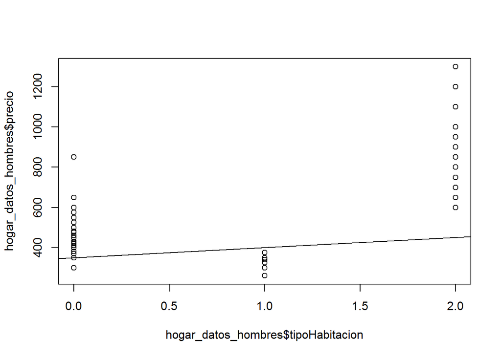

```r
plot(hogar_datos_hombres$tipoHabitacion,hogar_datos_hombres$precio)
abline(regresionHombres)
```

## Sin embargo, la regresión lineal multiple genera menos desviación

```r
regresionMultipleHombre <- lm(precio ~ ., data = hogar_datos_hombres)
desviacion <- summary(regresionMultipleHombre)$sigma
desviacion
```

```
## [1] 71.07852
```

# Estas son las gráficas que genera

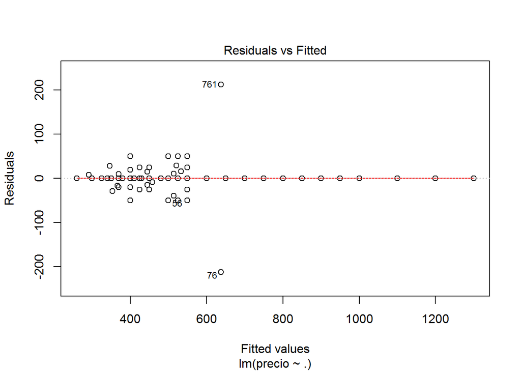

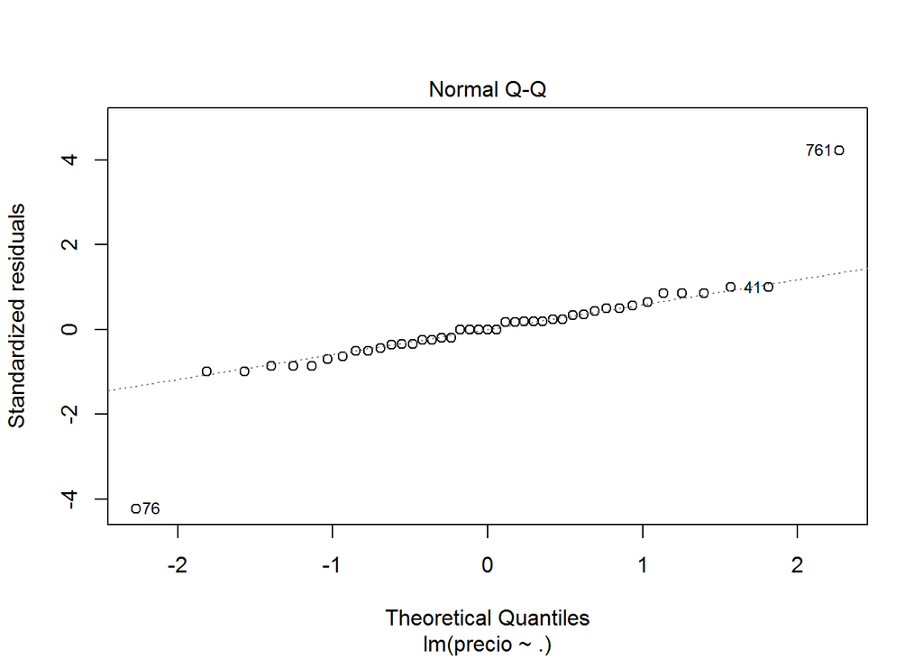

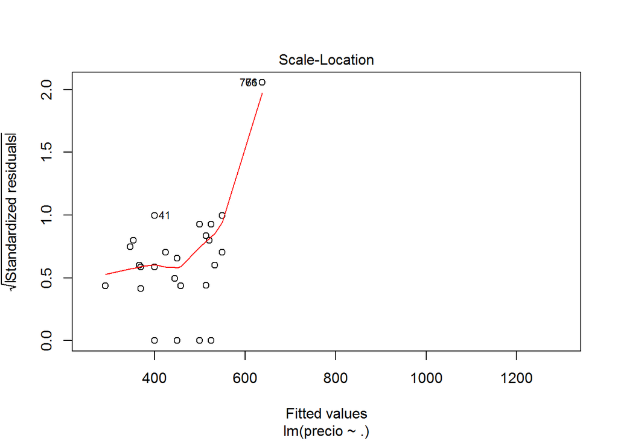

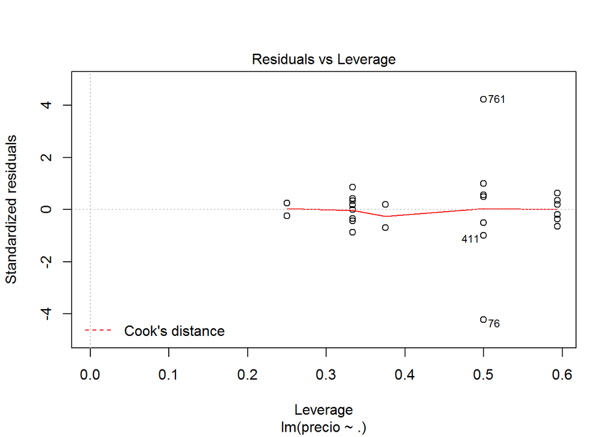

```r
plot(regresionMultipleHombre)
```

# Predicción de un precio para Hombre con Regresion lineal Multiple

```r
aux <- hogar_datos[1,]
aux$Tipo.de.Inmueble <- 0 # Apartamento
aux$ingreso <- '1' # Con entrada
aux$nroHabitaciones <- '2' # 2 habitaciones
aux$cocina <- '1' # Con cocina
aux$nroBanos <- '1' # Cantidad de baños
aux$calefaccion <- '0' # 1 para calefaccion
aux$condominio <- '0' # 1 para pagar condominio
aux$genero<- '0' # ambos generos
aux$cargosPorServicio <- '1' # 1 incluye cargos por servicios
aux$tipoHabitacion <- '2' # Apartamento completo
aux$lugar_origen <- 'Gallia San Giovanni' # Direccion o zona donde quieres
```

# Consulta de distancia usando el api de google

```r
api_url <- get_url(aux$lugar_origen, lugar_destino, api_key)
data <- get_data(api_url)
eryeison = parse_data(data)
if(eryeison$status == "OK"){
  duracion <- eryeison$duration$value
}
if (eryeison$status != "OK") {
  duracion <- '0'
}
aux$duracion <- as.factor(duracion)
```

# Predecimos el costo del hogar según la regresion multiple hecha en los pasos anteriores

```r
prediccion <- predict(regresionMultipleHombre, newdata = aux)
prediccion
```

```
##   1
## 890
```

## Utilizamos la data de las Mujeres

## Realizaremos una regresion simple con cada columna del dataset y buscaremos el que tenga menos desviación

## utilizando el sigma resultante de la funcion summary()

```r
desviacion <- 999
for (i in 1:12) {
  if (i!=10) {
    regresionMujeres <- lm(hogar_datos_mujeres$precio ~ hogar_datos_mujeres[,i])
    if (summary(regresionMujeres)$sigma < desviacion) {
      desviacion <- summary(regresionMujeres)$sigma
      regresionMujeresOptima <- regresionMujeres
    }
  }
}
```

## Al realizar la regresión con cada una de las columnas, la que tiene menos

## desviación es TipoHabitacion. Esta es la desviación y la gráfica generada.

```r
desviacion
```

```
## [1] 109.632
```

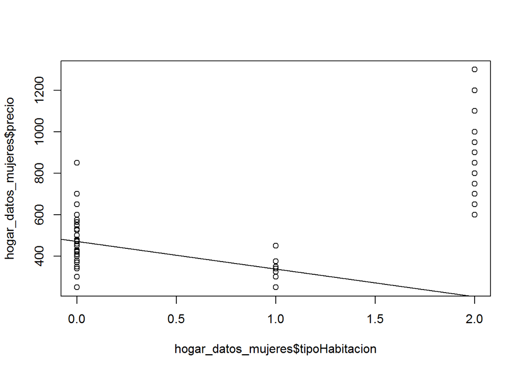

```r
plot(hogar_datos_mujeres$tipoHabitacion,hogar_datos_mujeres$precio)
abline(regresionMujeresOptima)
```

# Sin embargo, la regresión lineal multiple genera menos desviación

```r
regresionMultipleMujer <- lm(precio ~ ., data = hogar_datos_mujeres)
desviacion <- summary(regresionMultipleMujer)$sigma
desviacion
```

```
## [1] 84.7152
```

# Estas son las gráficas que genera

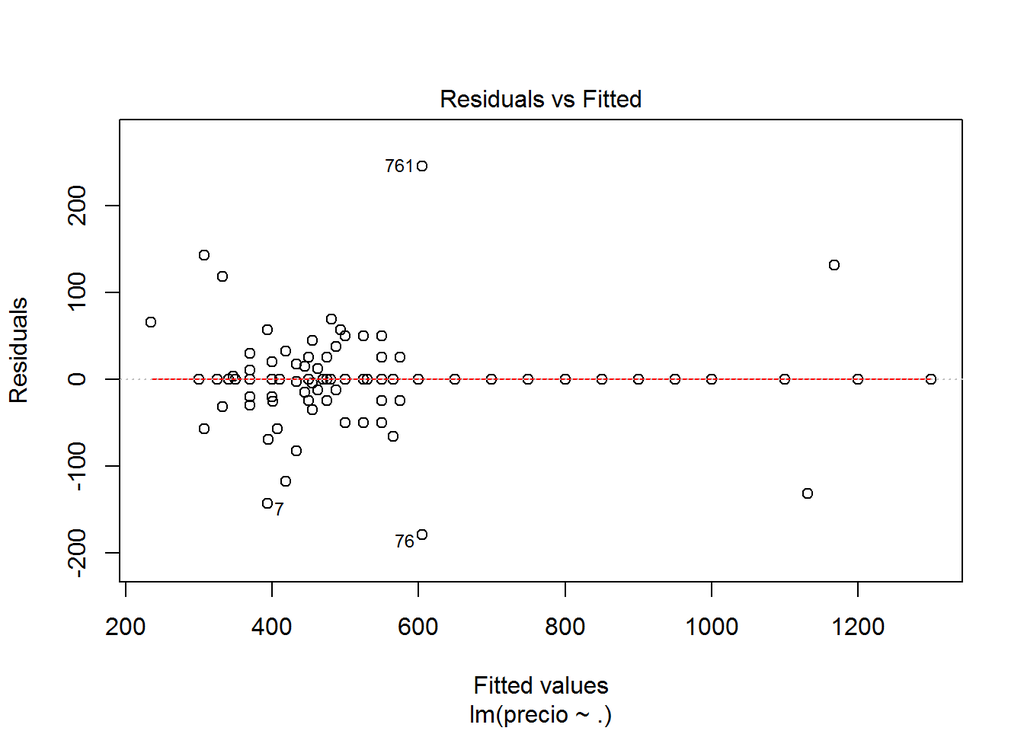

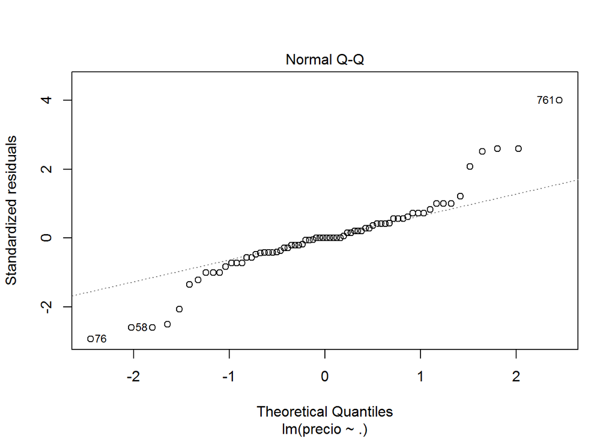

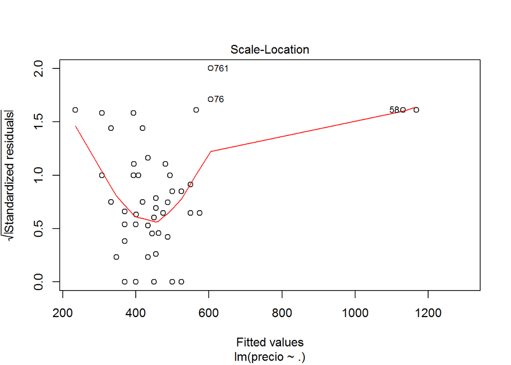

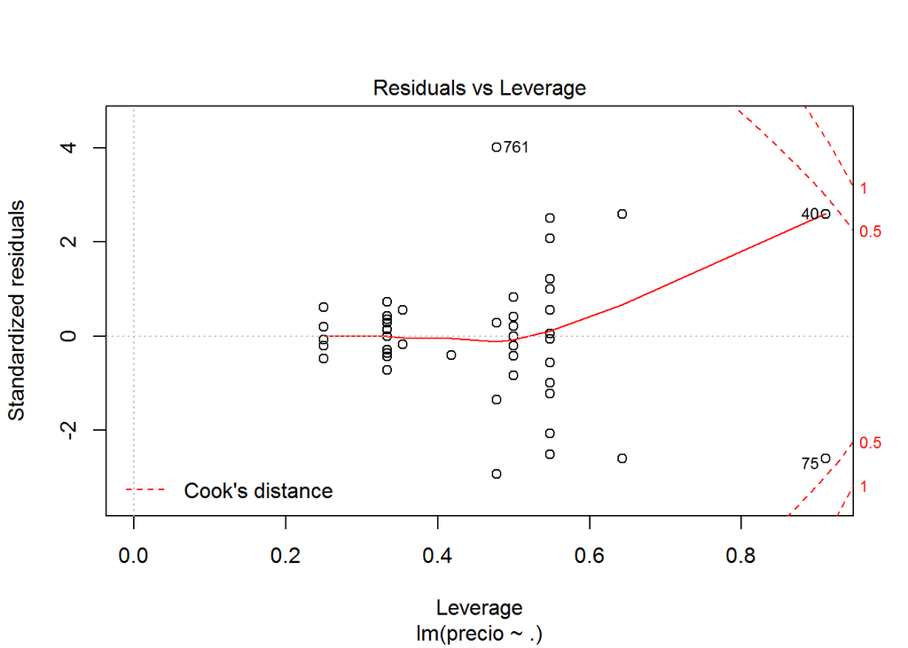

```r
plot(regresionMultipleMujer)
```

# Predicción de un precio para Mujer con Regresion lineal Multiple

# con los mismos datos, solo cambiando el género

```r
aux <- hogar_datos[1,]
aux$Tipo.de.Inmueble <- 0 # Apartamento
aux$ingreso <- '1' # Con entrada
aux$nroHabitaciones <- '2' # 2 habitaciones
aux$cocina <- '1' # Con cocina
aux$nroBanos <- '1' # Cantidad de baños
aux$calefaccion <- '0' # 1 para calefaccion
aux$condominio <- '0' # 1 para pagar condominio
aux$genero<- '1' # ambos generos
aux$cargosPorServicio <- '1' # 1 incluye cargos por servicios
aux$tipoHabitacion <- '2' # Apartamento completo
aux$lugar_origen <- 'Gallia San Giovanni' # Direccion o zona donde quieres
```

# La duración seria la misma del mismo lugar de origen

```r
aux$duracion <- as.factor(duracion)
```

# Predecimos el costo del hogar según la regrecion multiple hecha en los pasos anteriores

```r
prediccion <- predict(regresionMultipleMujer, newdata = aux)
prediccion
```

```
##        1
## 1652.749
```